# 第五周作业参考答案

## 第一题

**特别说明**：

这一题考察代价曲线的相关知识，首先，要明确归一化代价曲线和未归一化代价曲线的区别，其次，要注意代价曲线的横纵坐标表示的具体含义。

很明显如果作归一化代价曲线，横坐标是书上(2.24)，纵坐标是书上(2.25)，将两式整理一下，发现只需要用到(0,FPR)和(1,FNR)的信息，并不会受到cost01和cost10的影响，另一个需要注意的是，只有在归一化的情况下，线段下界围成的阴影面积才是期望总体代价。

如果是非归一化代价曲线，横坐标是书上(2.24)分子项，纵坐标是书上(2.25)分子项，将两式整理成y与x的关系发现它与cost01和cost10的比例有关，这时候，不同的cost比例关系对应的非归一化代价曲线就是有变化的，但同时，因为没有归一化，线段下界围成的阴影面积就不再是期望总体代价了。

这一题老师最开始的想法是想让大家作出cost01和cost10比例不同时，代价曲线的变化情况。针对这个变化的想法，显然需要用非归一化的代价曲线。但是，展示代价曲线变化与展示期望总体代价不可兼得，并且通常来说归一化曲线要更常用的，很少用到非归一化的。之后我会再跟王老师沟通一下，此次作业批改暂时以归一化的图为准，如果之后有其他沟通结果会再通知大家。

参考资料https://blog.csdn.net/twt9628/article/details/88711755

参考资料https://blog.csdn.net/algorithmPro/article/details/83870768

参考资料知乎回答第二条：https://www.zhihu.com/question/63492375/answer/247885093

## 范例一 2019202450-陈诺

#### 请根据例题中的测试得分绘制均衡代价曲线(注：$cost_{10}=1$,$cost_{01}=1$)。如果该数据是一个银行追查网络钓鱼攻击的一个学习器的训练数据，漏网的代价(FN)是误报代价(FP)的5倍($cost_{10}=1$,$cost_{01}=5$)那么请绘制代价曲线，如果是3倍，代价曲线会怎样变化，请比较三种不同代价下的代价曲线有什么变化

#### 代码实现

```python
import numpy as np
import pandas as pd
# 手动输入数据
b = np.array(['p','p','n','p','p','p','n','n','p','n','p','n','p','n','n','n','p','n','p','n',0.9,0.8,0.7,0.6,0.55,0.54,0.53,0.52,0.51,0.505,0.4,0.39,0.38,0.37,0.36,0.35,0.34,0.33,0.30,0.1]).reshape(2,20)
data = pd.DataFrame(b.T,columns=['Class','Score'],index=range(1,21))
# 展示数据
data
```

|  | Class | Score |
| --- | --- | --- |
| 1 | p | 0.9 |
| 2 | p | 0.8 |
| 3 | n | 0.7 |
| 4 | p | 0.6 |
| 5 | p | 0.55 |
| 6 | p | 0.54 |
| 7 | n | 0.53 |
| 8 | n | 0.52 |
| 9 | p | 0.51 |
| 10 | n | 0.505 |
| 11 | p | 0.4 |
| 12 | n | 0.39 |
| 13 | p | 0.38 |
| 14 | n | 0.37 |
| 15 | n | 0.36 |
| 16 | n | 0.35 |
| 17 | p | 0.34 |
| 18 | n | 0.33 |
| 19 | p | 0.3 |
| 20 | n | 0.1 |

```
ROC曲线上每一点在代价平面上对应的线段的下界的交点：
(0.0,0.0)
(0.25,0.2)
(0.571,0.329)
(0.667,0.3)
(1.0,0.0)
```

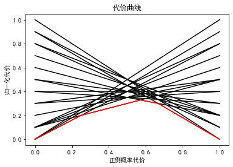

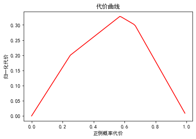

```python
import matplotlib.pyplot as plt
# cost_10表示实际为反例但预测成正例的代价，cost_01表示实际为正例但是预测为反例的代价
cost_10, cost_01 = 1, 1
score = np.array(data['Score'],float)
'''
画法一：ROC曲线
'''
# 计算ROC曲线殇的每个点
dot = np.array([[0,0]])
x,y = 0,0                                      # 初始位置
Class = np.array(data['Class'])
Score = np.array(data['Score'])
n1,n0 = np.sum(Class=='p'),np.sum(Class=='n')  # n1表示正样本的数量,n0表示负样本的数量
path1 = 1/n1
path0 = 1/n0                                   # path1表示正样本的移动距离,path0表示负样本的移动距离
for i in range(20):                            #计算点的坐标
    if Class[i] == 'p':
        y = y + path1
    else:
        x = x + path0
    dot = np.append(dot,[[x,y]],axis=0)
FPR = np.transpose(dot[:,0])                   # 假正例率
TPR = np.transpose(dot[:,1])                   # 真正例率

FNR = 1-TPR                                    # 假反例率
def inter(i,x0):
    point_x = np.array([])                     # 记录范围内的线段交点
    index_ = np.array([],int)                  # 记录范围内的线段交点对应的线段下标
    for j in range(len(FPR)):
        if j != i:                             # 与其他线段的交点
            x = (FPR[j]-FPR[i])/((FNR[i]-FPR[i])-(FNR[j]-FPR[j]))
            if (x>x0) and (x<=1):              # 交点横坐标比上一个交点大且在[0,1]内
                point_x = np.append(point_x,x)
                index_ = np.append(index_,j)
    if len(point_x) > 0:                       # 有交点
        j = np.argmin(point_x)                 # 取横坐标最小的交点的下标
        point_x = point_x[j]
        point_y = (FNR[i]-FPR[i])*point_x + FPR[i]
        if (point_y<0) or (point_y>1):         # 不在[0,1]内
            return len(FPR)-1,1,0
    else:
        return len(FPR)-1,1,0
    return index_[j],point_x,point_y           # 返回线段下标，交点横坐标，交点纵坐标
x_,y_ = np.array([0]),np.array([0])
a = np.array([])
for j in range(len(FPR)):
    if (FPR[j] == 0) and (FNR[j]-FPR[j]) != 0:
        a = np.append(a,FNR[j]-FPR[j])
i = np.argmin(a)
while(i < len(FPR)-1):
    i,point_x,point_y = inter(i,x_[-1])
    x_ = np.append(x_,point_x)
    y_ = np.append(y_,point_y)

print("ROC曲线上每一点在代价平面上对应的线段的下界的交点：")
for i in range(len(x_)):
    print("({},{})".format(round(x_[i],3),round(y_[i],3)))
#这两行用于解决图中中文乱码问题
plt.rcParams['font.sans-serif']=['SimHei']
plt.rcParams['axes.unicode_minus']=False

plt.figure()
# 画ROC曲线上每一点在代价平面上对应的线段
for i in range(len(FNR)):
    plt.plot([0,1],[FPR[i],FNR[i]],'-',color = 'black')
# 画代价曲线
plt.plot(x_,y_,'r-')
plt.title('代价曲线')
plt.xlabel('正例概率代价')
plt.ylabel('归一化代价')
plt.show()
'''
画法二：直接画
'''
plt.title('代价曲线')
plt.xlabel('正例概率代价')
plt.ylabel('归一化代价')
p_Cost = []
cost_Norm = []
for x in np.arange(0,1,0.01):
    p_Cost.append(x)
    ymin = 1
    for idx in range(len(FNR)):
        ymin = min(ymin,FNR[idx]*x+FPR[idx]*(1-x))
    cost_Norm.append(ymin)
plt.plot(p_Cost,cost_Norm,'r-')
plt.show()
```

#### 结果分析

绘制代价曲线的过程为计算出ROC曲线上的每一点，其坐标为（FPR,TPR），则可相应计算出FNR，然后在代价平面上绘制一条从（0,FPR）到（1,FNR）的线段，线段下的面积即表示了该条件下的期望总代价，所有线段的下界组成了代价曲线。

从绘制过程中可以看出，代价曲线的绘制与代价无关。因此，不同代价下的代价曲线不会有变化，而是取决于FNR和FPR的取值

## 范例二 2018200222-查王皓天

## Solution

从ROC曲线，可以得到不计代价的cost curve，横坐标是正例概率P(+)，纵坐标是error rate，进而，可以引入代价，得到横坐标是P(+)，纵坐标是归一化代价，再者，对横坐标归一化，横坐标是正例概率代价P+(C)，纵坐标是归一化代价，这张图是书上的图，但样子和第一张不计代价cost curve完全一样，横纵坐标意义发生了变化

因此我在第一题时同时画出三张图，便于比较，后面的题目就按照课本上定义只画第三张图（代价曲线）

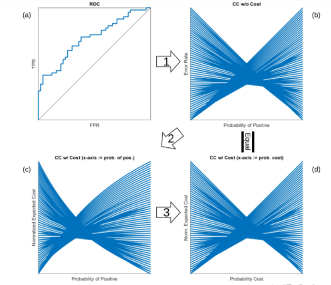

## Code

```
从左到右分别是cost01,cost10为（1，1）（5，1）（3，1）的图
从上到下xy坐标轴含义发生了变化
```

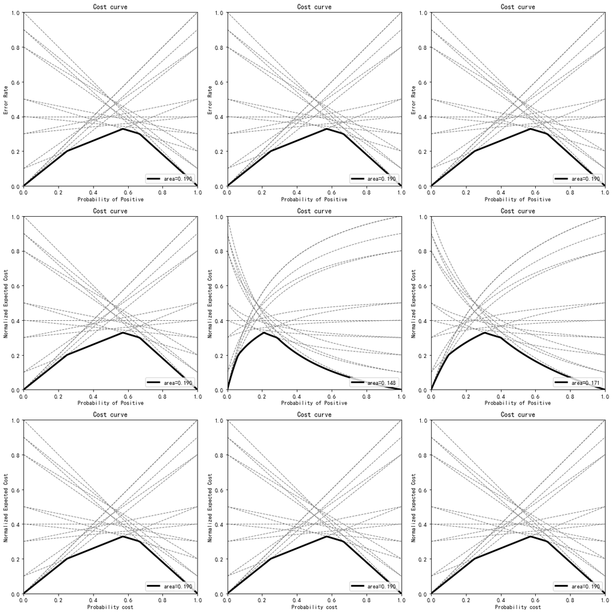

```python
import numpy as np
from sklearn.metrics import roc_curve
import matplotlib.pyplot as plt


print("从左到右分别是cost01,cost10为（1，1）（5，1）（3，1）的图")
print("从上到下xy坐标轴含义发生了变化")

#输入数据
y_true = np.array([1,1,0,1,1,1,0,0,1,0,1,0,1,0,0,0,1,0,1,0])
y_scores = np.array([0.9, 0.8,0.7,0.6,0.55,0.54,0.53,0.52,0.51,0.505,0.4,0.39,0.38,0.37,0.36,0.35,0.34,0.33,0.30,0.1])

#将score从高到低排序
y_pred_sort = np.sort(y_scores)[::-1]  # pred从大到小排序
index = np.argsort(y_scores)[::-1]     # 从大到小排序,提取序号，用于给y排序
y_true_sort=y_true[index]


# 获取roc曲线上的所有点
roc_fpr, roc_tpr, _ = roc_curve(y_true_sort, y_pred_sort)

#把0,0点也加进来
roc_tpr=np.append(roc_tpr,0)
roc_fpr=np.append(roc_fpr,0)

#获取fnr的值
roc_fnr=1-roc_tpr


"""第一张图"""

# 创建cost curve曲线数组
lines = []

#生成下界曲线的x值数组
thresholds = np.arange(0, 1.01, .01)

#创建下界曲线的y值数组
lower_envelope = []


# 将roc上的点加入曲线数组
for fpr, fnr in zip(roc_fpr, roc_fnr):
    lines.append((fpr, fnr))

#用min生成下界曲线y值
for x_value in thresholds:
    y_value = min([(fnr-fpr)*x_value+fpr for fpr,fnr in lines])
    lower_envelope.append(y_value)

#转换成numpy
lower_envelope = np.array(lower_envelope)

#利用积分计算围城面积
area = np.trapz(lower_envelope, thresholds)


plt.figure(figsize=(15,15))
plt.subplot(331)   #绘制四张图
#画曲线
for fpr,fnr in lines:
    plt.plot([0,1],[fpr,fnr],color="grey", lw=1, linestyle="--")

#画下界线
plt.plot(thresholds, lower_envelope, color="black", lw=3, label="area={:.3f}".format(area))


plt.xlim([0.0, 1.0])
plt.ylim([0.0, 1.0])
plt.xlabel("Probability of Positive")
plt.ylabel("Error Rate")
plt.title("Cost curve")
plt.legend(loc="lower right")


plt.subplot(332)
for fpr,fnr in lines:
    plt.plot([0,1],[fpr,fnr],color="grey", lw=1, linestyle="--")
plt.plot(thresholds, lower_envelope, color="black", lw=3, label="area={:.3f}".format(area))
plt.xlim([0.0, 1.0])
plt.ylim([0.0, 1.0])
plt.xlabel("Probability of Positive")
plt.ylabel("Error Rate")
plt.title("Cost curve")
plt.legend(loc="lower right")
plt.subplot(333)
for fpr,fnr in lines:
    plt.plot([0,1],[fpr,fnr],color="grey", lw=1, linestyle="--")
plt.plot(thresholds, lower_envelope, color="black", lw=3, label="area={:.3f}".format(area))
plt.xlim([0.0, 1.0])
plt.ylim([0.0, 1.0])
plt.xlabel("Probability of Positive")
plt.ylabel("Error Rate")
plt.title("Cost curve")
plt.legend(loc="lower right")

"""第二张图"""

# C(+|-)
cost_01=1
# C(-|+)
cost_10 =1

thresholds = np.arange(0, 1.01, .01)
lines_y=[]
for fpr,fnr in lines:
    cc_y=[]
    for x in thresholds:
        cc_y.append((fnr*x*cost_01+fpr*(1-x)*cost_10)/(x*cost_01+(1-x)*cost_10))
    lines_y.append(cc_y)

lower_envelope_2 = []
for x_value in thresholds:
    y_value = min([(fnr*x_value*cost_01+fpr*(1-x_value)*cost_10)/(x_value*cost_01+(1-x_value)*cost_10) for fpr,fnr in lines])
    lower_envelope_2.append(y_value)

#转换成numpy
lower_envelope_2 = np.array(lower_envelope_2)

#利用积分计算围城面积
area2 = np.trapz(lower_envelope_2, thresholds)

plt.subplot(334)   #绘制四张图
#画曲线
for i in range(len(lines_y)):
    plt.plot(thresholds,np.array(lines_y[i]),color="grey", lw=1, linestyle="--")

#画下界线
plt.plot(thresholds, lower_envelope_2, color="black", lw=3, label="area={:.3f}".format(area2))


plt.xlim([0.0, 1.0])
plt.ylim([0.0, 1.0])
plt.xlabel("Probability of Positive")
plt.ylabel("Normalized Expected Cost")
plt.title("Cost curve")
plt.legend(loc="lower right")

# C(+|-)
cost_01=5
# C(-|+)
cost_10 =1

thresholds = np.arange(0, 1.01, .01)
lines_y=[]
for fpr,fnr in lines:
    cc_y=[]
    for x in thresholds:
        cc_y.append((fnr*x*cost_01+fpr*(1-x)*cost_10)/(x*cost_01+(1-x)*cost_10))
    lines_y.append(cc_y)

lower_envelope_2 = []
for x_value in thresholds:
    y_value = min([(fnr*x_value*cost_01+fpr*(1-x_value)*cost_10)/(x_value*cost_01+(1-x_value)*cost_10) for fpr,fnr in lines])
    lower_envelope_2.append(y_value)

#转换成numpy
lower_envelope_2 = np.array(lower_envelope_2)

#利用积分计算围城面积
area2 = np.trapz(lower_envelope_2, thresholds)

plt.subplot(335)   #绘制四张图
#画曲线
for i in range(len(lines_y)):
    plt.plot(thresholds,np.array(lines_y[i]),color="grey", lw=1, linestyle="--")

#画下界线
plt.plot(thresholds, lower_envelope_2, color="black", lw=3, label="area={:.3f}".format(area2))


plt.xlim([0.0, 1.0])
plt.ylim([0.0, 1.0])
plt.xlabel("Probability of Positive")
plt.ylabel("Normalized Expected Cost")
plt.title("Cost curve")
plt.legend(loc="lower right")

# C(+|-)
cost_01=3
# C(-|+)
cost_10 =1

thresholds = np.arange(0, 1.01, .01)
lines_y=[]
for fpr,fnr in lines:
    cc_y=[]
    for x in thresholds:
        cc_y.append((fnr*x*cost_01+fpr*(1-x)*cost_10)/(x*cost_01+(1-x)*cost_10))
    lines_y.append(cc_y)

lower_envelope_2 = []
for x_value in thresholds:
    y_value = min([(fnr*x_value*cost_01+fpr*(1-x_value)*cost_10)/(x_value*cost_01+(1-x_value)*cost_10) for fpr,fnr in lines])
    lower_envelope_2.append(y_value)

#转换成numpy
lower_envelope_2 = np.array(lower_envelope_2)

#利用积分计算围城面积
area2 = np.trapz(lower_envelope_2, thresholds)

plt.subplot(336)   #绘制四张图
#画曲线
for i in range(len(lines_y)):
    plt.plot(thresholds,np.array(lines_y[i]),color="grey", lw=1, linestyle="--")

#画下界线
plt.plot(thresholds, lower_envelope_2, color="black", lw=3, label="area={:.3f}".format(area2))


plt.xlim([0.0, 1.0])
plt.ylim([0.0, 1.0])
plt.xlabel("Probability of Positive")
plt.ylabel("Normalized Expected Cost")
plt.title("Cost curve")
plt.legend(loc="lower right")

"""第三张图
Cost_norm=(FNR-FPR)P(+)Cost+FPR，可以看到和画图和cost没有任何关系，只是x y坐标发生了变化，完全仿照第一张图
"""


plt.subplot(337)
for fpr,fnr in lines:
    plt.plot([0,1],[fpr,fnr],color="grey", lw=1, linestyle="--")
plt.plot(thresholds, lower_envelope, color="black", lw=3, label="area={:.3f}".format(area))
plt.xlim([0.0, 1.0])
plt.ylim([0.0, 1.0])
plt.xlabel("Probability cost")
plt.ylabel("Normalized Expected Cost")
plt.title("Cost curve")
plt.legend(loc="lower right")
plt.subplot(338)
for fpr,fnr in lines:
    plt.plot([0,1],[fpr,fnr],color="grey", lw=1, linestyle="--")
plt.plot(thresholds, lower_envelope, color="black", lw=3, label="area={:.3f}".format(area))
plt.xlim([0.0, 1.0])
plt.ylim([0.0, 1.0])
plt.xlabel("Probability cost")
plt.ylabel("Normalized Expected Cost")
plt.title("Cost curve")
plt.legend(loc="lower right")
plt.subplot(339)
for fpr,fnr in lines:
    plt.plot([0,1],[fpr,fnr],color="grey", lw=1, linestyle="--")
plt.plot(thresholds, lower_envelope, color="black", lw=3, label="area={:.3f}".format(area))
plt.xlim([0.0, 1.0])
plt.ylim([0.0, 1.0])
plt.xlabel("Probability cost")
plt.ylabel("Normalized Expected Cost")
plt.title("Cost curve")
plt.legend(loc="lower right")


plt.tight_layout()
```

# 第二题

## 范例 2019202091-徐克丰

## 问题描述

如下数据是16次实验中的误分类结果，请比较测试误差率是否小于30%($\varepsilon\leq30\%$),实验中每次测试集$n=10$的误分类数量($mc$)如下，凭借这些数据使用t检验对该算法的泛化误差给出判断？请给出检验问题的表述，计算统计量，计算统计量的p-值，给出结论。

## 参数假设

$\varepsilon_0=0.3$

原假设$H_0:\varepsilon\leq\varepsilon_0$

备择假设$H_1:\varepsilon>\varepsilon_0$

显著性$\alpha=0.05$

## 代码实现

```python
import math
data=np.array([3,4,1,2,0,1,2,3,1,2,4,0,0,3,4,5])
data=data/10 #错误率
#计算样本均值和方差
mean=np.mean(data)
var=0
for i in range(16):
    var=var+pow(data[i]-mean,2)
var=var/15
k=16
#计算t统计量
t=math.sqrt(k)*(mean-0.3)/math.sqrt(var)
print('检验统计量T的值为：{:.3f}'.format(t))
```

```
检验统计量T的值为：-2.030
```

## 结果分析

计算出$t$统计量的值约为$T=-2.030$,由于$k=16$，所以$t$统计量服从自由度为15的$t$分布。下面还需要通过查表确定$p$值，如果$P(t>T)<\alpha$,就拒绝原假设$H_0$。通过查表，在自由度为15的$t$分布中，显著性水平$\alpha=0.05$的情况下，$T<t_{0.05}=1.7531$，说明$p>\alpha=0.05$，所以不能拒绝原假设$H_0$，可以在$\alpha=0.05$的显著性水平下认为该实验泛化误差$\varepsilon\leq30\%$。

# 第三题

补充说明：因为第一小问题目描述比较模糊，有的同学把测试集和训练集分开，并分别对两种模型作图（结果有8条线）；也有将数据集看作一个整体，并分别对两个模型作图（结果有4条线），这里都算正确。

# 范例 2018200222-查王皓天

## 第一小问

思路概述：本题主要发现，利用skleran函数绘制ROC图，它会做一个平滑，本来ROC的图应该只有横线和竖线，在roc_curve函数中绘制出来的居然出现了斜线，稳妥考虑还是利用自己写的函数绘制ROC图，AUC面积利用Sklearn函数进行计算。

## Code-1 绘图

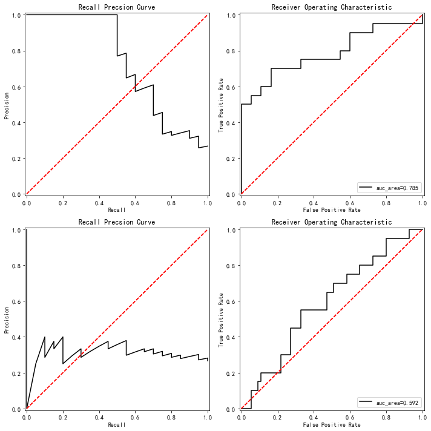

```python
import pandas as pd
import matplotlib
import numpy as np
import matplotlib.pyplot as plt
from sklearn.metrics import roc_curve
from sklearn import metrics

#编写函数
def PR_curve(y,pred):
    pos = np.sum(y == 1)   #计算正负例个数
    neg = np.sum(y == 0)
    Pre = []
    Rec = []
    for i, item in enumerate(pred):
        if i == 0:#因为计算precision的时候分母要用到i，当i为0时会出错，所以单独列出
            Pre.append(1)
            Rec.append(0)


        else:
            Pre.append(np.sum((y[:i] == 1)) /i)
            Rec.append(np.sum((y[:i] == 1)) / pos)


    #最后还要加一个末尾的点
    Pre.append(np.sum((y == 1)) /(pos+neg))
    Rec.append(np.sum((y == 1)) / pos)


    ## 画图
    plt.plot(Rec, Pre, 'k')


    plt.title('Recall Precsion Curve')
    plt.plot([(0, 0), (1, 1)], 'r--')
    plt.xlim([-0.01, 1.01])
    plt.ylim([-0.01, 01.01])
    plt.ylabel('Precision')
    plt.xlabel('Recall')

def ROC_curve(y,pred):    #同理绘制roc曲线
    pos = np.sum(y == 1)
    neg = np.sum(y == 0)
    tpr = []
    fpr = []

    for i,item in enumerate(pred):
        tpr.append(np.sum((y[:i+1] == 1)) / pos)
        fpr.append(np.sum((y[:i+1] == 0)) / neg)

    #添加0，0点
    fpr1=np.append(0,fpr)
    tpr1=np.append(0,tpr)

    #计算AUC
    auc_area=metrics.auc(fpr1, tpr1)

    #画图
    plt.plot(fpr1, tpr1, 'k',label="auc_area={:.3f}".format(auc_area))
    plt.title('Receiver Operating Characteristic')
    plt.plot([(0, 0), (1, 1)],'r--')
    plt.xlim([-0.01,1.01])
    plt.ylim([-0.01,01.01])
    plt.ylabel('True Positive Rate')
    plt.xlabel('False Positive Rate')
    plt.legend(loc="lower right")
    return tpr,fpr

#读入数据
dt=pd.read_excel('fishing.xlsx')
#筛选测试集
dt=dt[dt['验证集']==2]

score1=np.array(dt['模型1预测值: 钓鱼'])
score2=np.array(dt['模型2预测值: 钓鱼'])
y_true=np.array(dt['是否钓到鱼'])

#模型1两张图
y_pred_sort1 = np.sort(score1)[::-1]  # pred从大到小排序
index = np.argsort(score1)[::-1]     # 从大到小排序,提取序号，用于给y排序
y_true_sort1=y_true[index]


plt.figure(figsize=(10,10))

plt.subplot(221)
PR_curve(y_true_sort1, y_pred_sort1)

plt.subplot(222)
tpr1,fpr1=ROC_curve(y_true_sort1, y_pred_sort1)



#模型二两张图
y_pred_sort2 = np.sort(score2)[::-1]  # pred从大到小排序
index = np.argsort(score2)[::-1]     # 从大到小排序,提取序号，用于给y排序
y_true_sort2=y_true[index]

plt.subplot(223)
PR_curve(y_true_sort2, y_pred_sort2)


plt.subplot(224)
tpr2,fpr2=ROC_curve(y_true_sort2, y_pred_sort2)


plt.tight_layout()
```

## 最佳阈值-思考与讨论

如何对一个二分类问题求解最佳阈值有许多种办法，本题采用约登指数。约登指数也称正确指数，是确定阈值的常用办法，我们计算tnr+tpr-1(也即TPR-FPR)使其最大，即roc曲线上y-x最大的点即为最佳阈值。

另外，本题也让我发现，sklearn函数要慎用，其做了很多近似计算，roc_curve中的threshold根本就不是原来的阈值，做过处理了，我这里用的是最原始的排序数据，从大到小来计算最佳阈值

而且这个题目的数据比较特殊，会出现相同分数的点，所以不能用大于小于阈值来判断y_predict，必须用位置判断，因为完全可能两个分数一样的，一个被判为0，另一个被判为1，事实上，这件事情是违反逻辑的，这种边界情况确实不太好处理

## Code

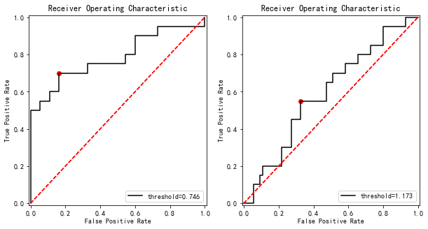

```
模型1的混淆矩阵是:
    0   1
0  46   9
1   6  14
模型2的混淆矩阵是:
    0   1
0  37  18
1   9  11
```

```python
def Find_Optimal_Cutoff(TPR, FPR, threshold):     #"""这里一定要注意，如果你的TPR包含0，0点，就会错位"""
    y= TPR - FPR
    Youden_index = np.argmax(y)  # Only the first occurrence is returned.
    #寻找到最佳阈值
    optimal_threshold = threshold[Youden_index]
    point = [FPR[Youden_index], TPR[Youden_index]]
    return optimal_threshold, point,Youden_index   #一定要返回位置


#确定两个模型的最佳阈值
optimal_th1, optimal_point1,index1 = Find_Optimal_Cutoff(np.array(tpr1),np.array(fpr1),y_pred_sort1)
optimal_th2, optimal_point2,index2 = Find_Optimal_Cutoff(np.array(tpr2),np.array(fpr2),y_pred_sort2)

#为了画图还是把0，0加上
fpr1_=np.append(0,fpr1)
tpr1_=np.append(0,tpr1)
fpr2_=np.append(0,fpr2)
tpr2_=np.append(0,tpr2)


plt.figure(figsize=(10,5))
plt.subplot(121)
#将阈值点标出
plt.plot(optimal_point1[0], optimal_point1[1], marker='o', color='r')
plt.plot(list(fpr1_), list(tpr1_),'k',label="threshold={:.3f}".format(optimal_th1))
plt.title('Receiver Operating Characteristic')
plt.plot([(0, 0), (1, 1)],'r--')
plt.xlim([-0.01,1.01])
plt.ylim([-0.01,01.01])
plt.ylabel('True Positive Rate')
plt.xlabel('False Positive Rate')
plt.legend(loc="lower right")

plt.subplot(122)
plt.plot(optimal_point2[0], optimal_point2[1], marker='o', color='r')
plt.plot(list(fpr2_), list(tpr2_),'k',label="threshold={:.3f}".format(optimal_th2))
plt.title('Receiver Operating Characteristic')
plt.plot([(0, 0), (1, 1)],'r--')
plt.xlim([-0.01,1.01])
plt.ylim([-0.01,01.01])
plt.ylabel('True Positive Rate')
plt.xlabel('False Positive Rate')
plt.legend(loc="lower right")

plt.show()
#通过阈值来预测
Y_pred1=[]
Y_pred2=[]


for i in range(len(y_true_sort1)):
    #我没有用值，而是用位置判断
    if i<=index1:
        Y_pred1.append(1)
    else:
        Y_pred1.append(0)

for i in range(len(y_true_sort2)):
    if i<=index2:
        Y_pred2.append(1)
    else:
        Y_pred2.append(0)


from sklearn.metrics import confusion_matrix


C1=confusion_matrix(y_true_sort1, Y_pred1)
C2=confusion_matrix(y_true_sort2, Y_pred2)

df1 = pd.DataFrame(C1)
df2 = pd.DataFrame(C2)
print("模型1的混淆矩阵是:")
print(df1)
print("模型2的混淆矩阵是:")
print(df2)
```

## code

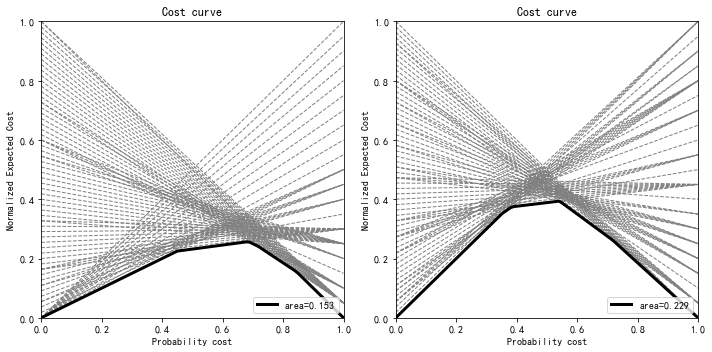

```python
plt.figure(figsize=(10,5))

lines = []

#生成下界曲线的x值数组
thresholds = np.arange(0, 1.01, .01)

#创建下界曲线的y值数组
lower_envelope = []

fnr1_=1-tpr1_
# 将roc上的点加入曲线数组
for fpr, fnr in zip(fpr1_, fnr1_):
    lines.append((fpr, fnr))

#用min生成下界曲线y值
for x_value in thresholds:
    y_value = min([(fnr-fpr)*x_value+fpr for fpr,fnr in lines])
    lower_envelope.append(y_value)

#转换成numpy
lower_envelope = np.array(lower_envelope)

#利用积分计算围城面积
area = np.trapz(lower_envelope, thresholds)

plt.subplot(121)   #绘制四张图
#画曲线
for fpr,fnr in lines:
    plt.plot([0,1],[fpr,fnr],color="grey", lw=1, linestyle="--")

#画下界线
plt.plot(thresholds, lower_envelope, color="black", lw=3, label="area={:.3f}".format(area))


plt.xlim([0.0, 1.0])
plt.ylim([0.0, 1.0])
plt.xlabel("Probability cost")
plt.ylabel("Normalized Expected Cost")
plt.title("Cost curve")
plt.legend(loc="lower right")

lines = []

#生成下界曲线的x值数组
thresholds = np.arange(0, 1.01, .01)

#创建下界曲线的y值数组
lower_envelope = []

fnr2_=1-tpr2_
# 将roc上的点加入曲线数组
for fpr, fnr in zip(fpr2_, fnr2_):
    lines.append((fpr, fnr))

#用min生成下界曲线y值
for x_value in thresholds:
    y_value = min([(fnr-fpr)*x_value+fpr for fpr,fnr in lines])
    lower_envelope.append(y_value)

#转换成numpy
lower_envelope = np.array(lower_envelope)

#利用积分计算围城面积
area = np.trapz(lower_envelope, thresholds)

plt.subplot(122)   #绘制四张图
#画曲线
for fpr,fnr in lines:
    plt.plot([0,1],[fpr,fnr],color="grey", lw=1, linestyle="--")

#画下界线
plt.plot(thresholds, lower_envelope, color="black", lw=3, label="area={:.3f}".format(area))


plt.xlim([0.0, 1.0])
plt.ylim([0.0, 1.0])
plt.xlabel("Probability cost")
plt.ylabel("Normalized Expected Cost")
plt.title("Cost curve")
plt.legend(loc="lower right")

plt.tight_layout()
```

# 第四题

## 范例 2019202091-徐克丰

## 第(1)问

## 参数假设

经验阈值设为0.5

## 代码实现

```python
#定义函数进行标签分类
def modelsort(predict):
    list0=[]
    for i in range(len(predict)):
        if predict[i]>0.5:
            list0.append(1)
        else:
            list0.append(0)
    return list0
#读入数据，将5折的数据存储到列表里，便于存取
data=pd.read_excel('手写体数据.xlsx')
kfold=[data.iloc[0:96,:],data.iloc[96:192,:],data.iloc[192:288,:],data.iloc[288:384,:],data.iloc[384:480,:]]
listp1=[];listp2=[];listp3=[]
listr1=[];listr2=[];listr3=[]
#计算三个模型的宏查准率，宏查全率
for i in range(5):
    confmat1=confusion_matrix(y_true=kfold[i].loc[:,['数据标签']].values,y_pred=modelsort(kfold[i].loc[:,['模型1预测']].values))
    confmat2=confusion_matrix(y_true=kfold[i].loc[:,['数据标签']].values,y_pred=modelsort(kfold[i].loc[:,['模型2预测']].values))
    confmat3=confusion_matrix(y_true=kfold[i].loc[:,['数据标签']].values,y_pred=modelsort(kfold[i].loc[:,['模型3预测']].values))
    listp1.append(confmat1[1][1]/(confmat1[1][1]+confmat1[0][1]))
    listr1.append(confmat1[1][1]/(confmat1[1][1]+confmat1[1][0]))
    listp2.append(confmat2[1][1]/(confmat2[1][1]+confmat2[0][1]))
    listr2.append(confmat2[1][1]/(confmat2[1][1]+confmat2[1][0]))
    listp3.append(confmat3[1][1]/(confmat3[1][1]+confmat3[0][1]))
    listr3.append(confmat3[1][1]/(confmat3[1][1]+confmat3[1][0]))
print('模型1的宏查准率macro-P1=%f'%(np.mean(listp1)))
print('模型1的宏查全率macro-R1=%f'%(np.mean(listr1)))
print('模型2的宏查准率macro-P2=%f'%(np.mean(listp2)))
print('模型2的宏查全率macro-R2=%f'%(np.mean(listr2)))
print('模型3的宏查准率macro-P3=%f'%(np.mean(listp3)))
print('模型3的宏查全率macro-R3=%f'%(np.mean(listr3)))
#计算三个模型的微查准率，微查全率
confmat1=np.array([[0,0],[0,0]])
confmat2=np.array([[0,0],[0,0]])
confmat3=np.array([[0,0],[0,0]])
for i in range(5):
    confmat1=confmat1+confusion_matrix(y_true=kfold[i].loc[:,['数据标签']].values,y_pred=modelsort(kfold[i].loc[:,['模型1预测']].values))
    confmat2=confmat2+confusion_matrix(y_true=kfold[i].loc[:,['数据标签']].values,y_pred=modelsort(kfold[i].loc[:,['模型2预测']].values))
    confmat3=confmat3+confusion_matrix(y_true=kfold[i].loc[:,['数据标签']].values,y_pred=modelsort(kfold[i].loc[:,['模型3预测']].values))
confmat1=confmat1/5
confmat2=confmat2/5
confmat3=confmat3/5
print()
print('模型1的微查准率micro-P1=%f'%(confmat1[1][1]/(confmat1[1][1]+confmat1[0][1])))
print('模型1的微查全率micro-R1=%f'%(confmat1[1][1]/(confmat1[1][1]+confmat1[1][0])))
print('模型2的微查准率micro-P2=%f'%(confmat2[1][1]/(confmat2[1][1]+confmat2[0][1])))
print('模型2的微查全率micro-R2=%f'%(confmat2[1][1]/(confmat2[1][1]+confmat2[1][0])))
print('模型3的微查准率micro-P3=%f'%(confmat3[1][1]/(confmat3[1][1]+confmat3[0][1])))
print('模型3的微查全率micro-R3=%f'%(confmat3[1][1]/(confmat3[1][1]+confmat3[1][0])))
#kfold2=data[98:193]
#kfold3=data[194:289]
#kfold4=data[290:385]
#kfold5=data[386,480]
#kfold=np.array([data[2:97],data[98:193],data[194:289],data[290:385],data[386,480]])
#print(kfold5)
```

```
模型1的宏查准率macro-P1=0.829403
模型1的宏查全率macro-R1=0.858333
模型2的宏查准率macro-P2=0.530520
模型2的宏查全率macro-R2=0.504167
模型3的宏查准率macro-P3=0.534917
模型3的宏查全率macro-R3=0.545833

模型1的微查准率micro-P1=0.827309
模型1的微查全率micro-R1=0.858333
模型2的微查准率micro-P2=0.530702
模型2的微查全率micro-R2=0.504167
模型3的微查准率micro-P3=0.532520
模型3的微查全率micro-R3=0.545833
```

## 第(2)问

## 代码实现

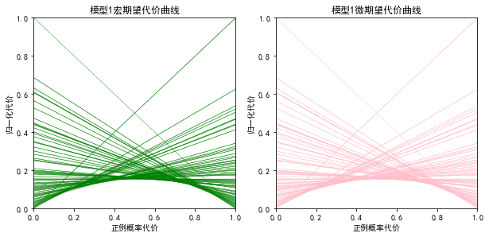

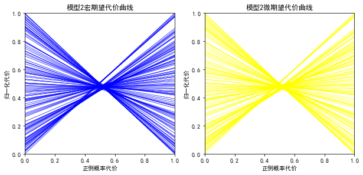

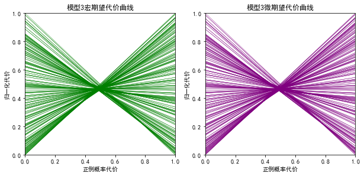

```python
#绘制宏期望代价曲线，即取一组阈值，每次计算5个混淆矩阵所得P,R数据的均值，绘制宏期望代价曲线
#定义函数进行标签分类
def modelsort2(predict,val):
    list0=[]
    for i in range(len(predict)):
        if predict[i]>=val:
            list0.append(1)
        else:
            list0.append(0)
    return list0
#首先获得三个模型的阈值各一组
fpr1,tpr1,thresholds1=roc_curve(data.loc[:,['数据标签']].values,data.loc[:,['模型1预测']].values)
fpr2,tpr2,thresholds2=roc_curve(data.loc[:,['数据标签']].values,data.loc[:,['模型2预测']].values)
fpr3,tpr3,thresholds3=roc_curve(data.loc[:,['数据标签']].values,data.loc[:,['模型3预测']].values)

#绘制模型1的宏，微期望代价曲线
#对于每个阈值，有5个混淆矩阵,计算此阈值下的宏tpr与fpr
listtpr1=[]
listfpr1=[]
for j in range(len(thresholds1)):
    fpr1=list();tpr1=list()
    for i in range(5):
        confmat1=confusion_matrix(y_true=kfold[i].loc[:,['数据标签']].values,y_pred=modelsort2(kfold[i].loc[:,['模型1预测']].values,thresholds1[j]))
        tpr1.append(confmat1[1][1]/(confmat1[1][1]+confmat1[1][0]))
        fpr1.append(confmat1[0][1]/(confmat1[0][1]+confmat1[0][0]))
    listtpr1.append(np.mean(tpr1))
    listfpr1.append(np.mean(fpr1))

plt.figure(figsize=(10,15))
listfnr1=1-np.array(listtpr1)
plt.subplot(321)
for i in range(len(listfnr1)):
    plt.plot([0,1],[listfpr1[i],listfnr1[i]],linewidth=0.4,color='green')
plt.xlim([0,1])
plt.ylim([0,1])
plt.title('模型1宏期望代价曲线')
plt.xlabel('正例概率代价')
plt.ylabel('归一化代价')
#模型1的微期望代价曲线
listmtpr1=[]
listmfpr1=[]
for j in range(len(thresholds1)):
    confmat1=np.array([[0,0],[0,0]])
    for i in range(5):
        confmat1=confmat1+confusion_matrix(y_true=kfold[i].loc[:,['数据标签']].values,y_pred=modelsort2(kfold[i].loc[:,['模型1预测']].values,thresholds1[j]))
    confmat1=confmat1/5
    listmtpr1.append(confmat1[1][1]/(confmat1[1][1]+confmat1[1][0]))
    listmfpr1.append(confmat1[0][1]/(confmat1[0][1]+confmat1[0][0]))

listmfnr1=1-np.array(listmtpr1)
plt.subplot(322)
for i in range(len(listmfnr1)):
    plt.plot([0,1],[listmfpr1[i],listmfnr1[i]],linewidth=0.4,color='pink')
plt.xlim([0,1])
plt.ylim([0,1])
plt.title('模型1微期望代价曲线')
plt.xlabel('正例概率代价')
plt.ylabel('归一化代价')



#绘制模型2的宏，微期望代价曲线
#对于每个阈值，有5个混淆矩阵,计算此阈值下的宏tpr与fpr
listtpr2=[]
listfpr2=[]
for j in range(len(thresholds2)):
    fpr2=list();tpr2=list()
    for i in range(5):
        confmat2=confusion_matrix(y_true=kfold[i].loc[:,['数据标签']].values,y_pred=modelsort2(kfold[i].loc[:,['模型2预测']].values,thresholds2[j]))
        tpr2.append(confmat2[1][1]/(confmat2[1][1]+confmat2[1][0]))
        fpr2.append(confmat2[0][1]/(confmat2[0][1]+confmat2[0][0]))
    listtpr2.append(np.mean(tpr2))
    listfpr2.append(np.mean(fpr2))

plt.figure(figsize=(10,15))
listfnr2=1-np.array(listtpr2)
plt.subplot(323)
for i in range(len(listfnr2)):
    plt.plot([0,1],[listfpr2[i],listfnr2[i]],linewidth=0.4,color='blue')
plt.xlim([0,1])
plt.ylim([0,1])
plt.title('模型2宏期望代价曲线')
plt.xlabel('正例概率代价')
plt.ylabel('归一化代价')
#模型2的微期望代价曲线
listmtpr2=[]
listmfpr2=[]
for j in range(len(thresholds2)):
    confmat2=np.array([[0,0],[0,0]])
    for i in range(5):
        confmat2=confmat2+confusion_matrix(y_true=kfold[i].loc[:,['数据标签']].values,y_pred=modelsort2(kfold[i].loc[:,['模型2预测']].values,thresholds2[j]))
    confmat2=confmat2/5
    listmtpr2.append(confmat2[1][1]/(confmat2[1][1]+confmat2[1][0]))
    listmfpr2.append(confmat2[0][1]/(confmat2[0][1]+confmat2[0][0]))

listmfnr2=1-np.array(listmtpr2)
plt.subplot(324)
for i in range(len(listmfnr2)):
    plt.plot([0,1],[listmfpr2[i],listmfnr2[i]],linewidth=0.4,color='yellow')
plt.xlim([0,1])
plt.ylim([0,1])
plt.title('模型2微期望代价曲线')
plt.xlabel('正例概率代价')
plt.ylabel('归一化代价')

#绘制模型3的宏，微期望代价曲线
#对于每个阈值，有5个混淆矩阵,计算此阈值下的宏tpr与fpr
listtpr3=[]
listfpr3=[]
for j in range(len(thresholds3)):
    fpr3=list();tpr3=list()
    for i in range(5):
        confmat3=confusion_matrix(y_true=kfold[i].loc[:,['数据标签']].values,y_pred=modelsort2(kfold[i].loc[:,['模型3预测']].values,thresholds3[j]))
        tpr3.append(confmat3[1][1]/(confmat3[1][1]+confmat3[1][0]))
        fpr3.append(confmat3[0][1]/(confmat3[0][1]+confmat3[0][0]))
    listtpr3.append(np.mean(tpr3))
    listfpr3.append(np.mean(fpr3))

plt.figure(figsize=(10,15))
listfnr3=1-np.array(listtpr3)
plt.subplot(325)
for i in range(len(listfnr3)):
    plt.plot([0,1],[listfpr3[i],listfnr3[i]],linewidth=0.4,color='green')
plt.xlim([0,1])
plt.ylim([0,1])
plt.title('模型3宏期望代价曲线')
plt.xlabel('正例概率代价')
plt.ylabel('归一化代价')
#模型2的微期望代价曲线
listmtpr3=[]
listmfpr3=[]
for j in range(len(thresholds3)):
    confmat3=np.array([[0,0],[0,0]])
    for i in range(5):
        confmat3=confmat3+confusion_matrix(y_true=kfold[i].loc[:,['数据标签']].values,y_pred=modelsort2(kfold[i].loc[:,['模型3预测']].values,thresholds3[j]))
    confmat3=confmat3/5
    listmtpr3.append(confmat3[1][1]/(confmat3[1][1]+confmat3[1][0]))
    listmfpr3.append(confmat3[0][1]/(confmat3[0][1]+confmat3[0][0]))

listmfnr3=1-np.array(listmtpr3)
plt.subplot(326)
for i in range(len(listmfnr3)):
    plt.plot([0,1],[listmfpr3[i],listmfnr3[i]],linewidth=0.4,color='purple')
plt.xlim([0,1])
plt.ylim([0,1])
plt.title('模型3微期望代价曲线')
plt.xlabel('正例概率代价')
plt.ylabel('归一化代价')
```

## 结果分析

观察三种模型的代价曲线，发现期望总体代价模型1最小，模型2与模型3期望总体代价类似，模型3的期望总体代价略小于模型2,说明模型1的性能更优。另外，对比每一个模型的宏期望代价和微期望代价曲线，发现差异不大。

# 第五题

## 范例 2019202449-舒纯新

## a小问

在Cameraman数据上，分别比较四种算法，请问哪一种算法的信噪比高于20%。

### 问题分析

设信噪比为m,建立原假设与备择假设： $$原假设H_0:m≤20\%$$ $$备择假设H_1:m>20\%$$ 取阈值$\alpha=0.05$

### 代码实现

```python
from scipy import stats
Cameraman = ([26.96,25.82,24.39,22.98,21.70,20.52,19.50,18.59,17.75],
            [27.52,26.20,24.74,23.45,22.29,21.34,20.46,19.70,19.15],
            [28.75,26.56,24.84,23.56,22.57,21.75,21.05,20.43,19.89],
            [27.87,26.83,25.86,24.99,24.15,23.38,22.74,22.14,21.61])
for i in range(4):
    res = stats.ttest_1samp(Cameraman[i],20) #信噪比与20%检验
    print("第",i+1,"种方法的结果是")
    print("t statistic:",round(res.statistic,5))
    print("P Value:",round(res.pvalue/2,5),'\n')#进行单侧检验要除以2
```

```
第 1 种方法的结果是
t statistic: 1.87232
P Value: 0.04903

第 2 种方法的结果是
t statistic: 2.82437
P Value: 0.01117

第 3 种方法的结果是
t statistic: 3.29838
P Value: 0.00544

第 4 种方法的结果是
t statistic: 6.11872
P Value: 0.00014
```

### 结果分析

取阈值为0.05时，由于是单侧检验，对于第一步计算得到的p值要除以二，得到四种方法的p值都小于0.05，所以都拒绝原假设，即四种算法的信噪比评分都高于20%。

## b小问

在$\sigma=20$上，四种算法是否有显著差异?

### 问题分析

建立原假设与备择假设： $$原假设H_0:四种算法没有显著差异$$ $$备择假设H_1:四种算法有显著差异$$ 取阈值$\alpha=0.05$

### 代码实现

```python
import scipy.stats as stats
algorithm= ([30.42,29.25,29.09,26.96,29.18],
             [30.69,29.42,29.37,27.52,29.49],
             [30.61,29.26,28.50,28.75,28.95],
             [31.57,29.74,29.64,27.87,29.76])
print("Friedman检验结果为：")
stats.friedmanchisquare(algorithm[0],algorithm[1],algorithm[2],algorithm[3])
```

```
Friedman检验结果为：
```

```
FriedmanchisquareResult(statistic=9.719999999999999, pvalue=0.021102512414100237)
```

### 结论分析

p值小于阈值0.05，拒绝原假设，所以在$\sigma=20$上四种算法有显著差异。